# Interrupted time series in R

# Intro - Using this notebook

This workshop uses an [R Markdown](http://rmarkdown.rstudio.com) Notebook. When you execute code within the notebook, the results appear beneath the code.

Within each `{r}` chunk, the R code will run when you press the ‘▶’ button. This is the same R code you can use in any R session or script. Try executing this chunk by clicking the *Run* (‘▶’) button within the chunk or by placing your cursor inside it and pressing *Ctrl+Shift+Enter*.

Load the required package `tidyverse` to get started:

```r
library(tidyverse)
# if `tidyverse` isn't installed, run `install.packages("tidyverse")` first then re-run the `library(tidyverse)` command first.

knitr::opts_chunk$set(messages = FALSE)
```

Once you have run all chunks, when you save the notebook, an HTML file containing the code and output will be saved alongside it. You can click **Preview** above to see the output as you edit and re-run (this will only show you the results of code chunks you have already run), or **Knit to HTML** from the drop-down menu next to Preview to run all chunks again and create an HTML output file.

Throughout this file we’ll be using the packages `dplyr` and `ggplot2` (included in `tidyverse`). Both of these have ‘cheatsheets’ if you’re not familiar with them (available to download [here](https://github.com/rstudio/cheatsheets/raw/master/data-visualization.pdf) and [here](https://github.com/rstudio/cheatsheets/raw/master/data-transformation.pdf))

# Interrupted Time Series Analysis - England’s Teenage Pregnancy Strategy

Interrupted time series (*ITS*) analyses provide a method for evaluating the impact of an exposure on a measured outcome. They have the advantage that they compare before/after trends and therefore don’t *need* a control group (but controls can be used for more robust comparisons - as we shall see). They can account for baseline trends and therefore control for some degree of secular change. One limitation is they are susceptible to other exposures producing spurious results, but controls can be used to overcome this.

There are several ways of doing an ITS analysis. We’ll choose a simple approach of a segmented regression model.

More details on how this can be used can be found in these two papers:

James Lopez Bernal, Steven Cummins, Antonio Gasparrini, Interrupted time series regression for the evaluation of public health interventions: a tutorial, International Journal of Epidemiology, Volume 46, Issue 1, February 2017, Pages 348–355, https://doi.org/10.1093/ije/dyw098

James Lopez Bernal, Steven Cummins, Antonio Gasparrini, The use of controls in interrupted time series studies of public health interventions, International Journal of Epidemiology, Volume 47, Issue 6, December 2018, Pages 2082–2093, https://doi.org/10.1093/ije/dyy135

## Introduction - The Teenage Pregnancy Strategy

The Teenage Pregnancy Strategy (TPS) was launched in England in 1999 to address high rates of teenage pregnancy. A stated goal was a 50% reduction in under-18 pregnancy rates.

## The data

The main dataset we will use here is under-18 pregnancy rates in England from 1992 to 2016 (data available from The Office for National Statisics). If the TPS had had an effect on teenage pregnancy rates, we would expect to see a change in this target population and outcome.

## Load the data and have a look

```r
england <- read_csv("data/England.csv") # Replace `___` with the path to `England.csv` (hint: in `data` folder)
england
```

| Country | Year | preg_rate |
| --- | --- | --- |
| England | 1992 | 43.3 |
| England | 1993 | 42.1 |
| England | 1994 | 41.6 |
| England | 1995 | 41.6 |
| England | 1996 | 45.9 |
| England | 1997 | 45.5 |
| England | 1998 | 46.6 |
| England | 1999 | 44.8 |
| England | 2000 | 43.6 |
| England | 2001 | 42.5 |

[output cut: 15 more lines]

This includes the variables:

- `Country`: here only England data is included (to denote ‘exposed’ unit)
- `Year`: from earliest observation (1992) to latest (2016)
- `preg_rate`: rate of pregnancies to women aged under-18 per 1,000

## Let’s have a look at the data in a scatter plot

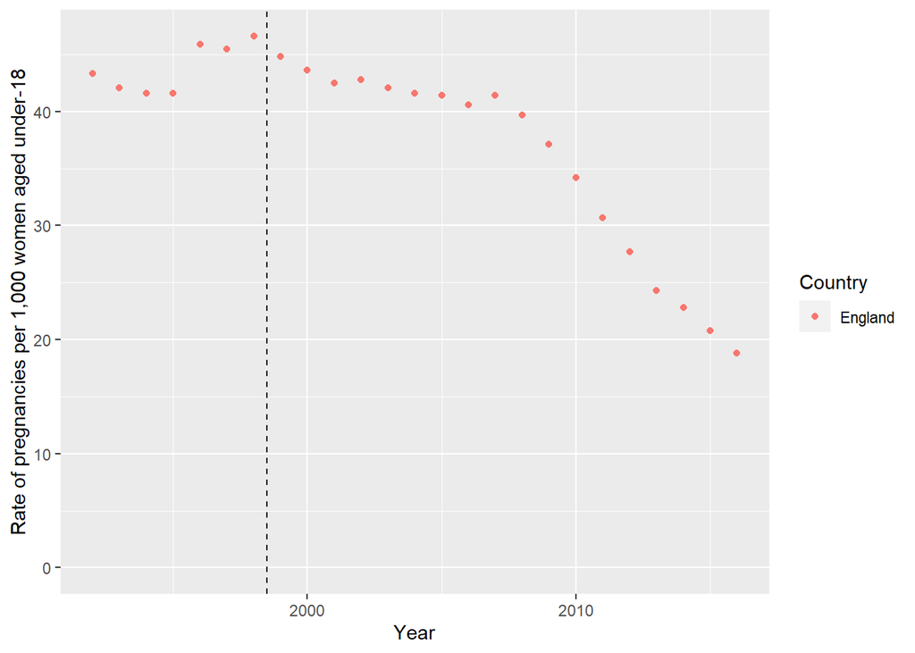

```r
eng_plot <- england %>%
  ggplot(aes(x = Year, y = preg_rate, colour = Country)) +
  geom_point() + # add scatter points; Hint: You'll find a function for this in the ggplot2 cheatsheet!

  # Add in a line between 1998 and 1999 to mark Strategy launch
  geom_vline(xintercept = 1998.5, linetype = "dashed") +

  # Label to make axis clearer and include 0 in y axis range
  ylab("Rate of pregnancies per 1,000 women aged under-18") +
  ylim(0, NA)

eng_plot
```

Your graph should look like [this](https://i.imgur.com/YS0Gxm0.png).

**View inline in rendered file**

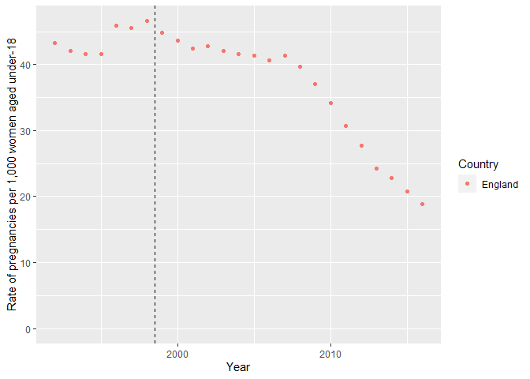

> What do you notice about pregnancy rate trends before and after the 1999 Strategy launch? Are these trends (roughly) linear?

It seems that an interrupted time series model could work here to detect changes in pregnancy rates consistent with the launch of the strategy. I propose that a slope change at 1999 with a possible level change best represents the impact model seen here (see Lopez Bernal et al., 2017; Figure 2). Do you agree?

## Fitting a linear model

To test whether level or trend changes were seen at 1999 we fit a linear model with coefficients for:

- Baseline (pre-1992) pregnancy rate
- Pre-strategy trend change by year (‘Time’)
- Level change at strategy launch (‘Level’)
- Trend change from strategy launch (‘Trend’)

This gives us the following equation:

$Rate = \beta_0+\beta_1*Time+\beta_2*Level+\beta_3*Trend+\epsilon$

To do this, we first need to create dummy variables for Time, Level and Trend:

- ‘Time’ should begin with 1 in 1992 and increment by 1 each year.
- ‘Level’ should be 0 before the strategy launch and 1 in all years after
- ‘Trend’ should be 0 before the strategy launch, begin with 1 in 1999 at strategy launch and increment by 1 each year

Let’s add these variables to a new dataframe for testing:

```r
# The `ifelse(a, b, c)` function says "If 'a' is TRUE, return 'b', else return 'c'"
# An example is given in setting Level: "If Year is 1999 or later, set Level = 1, else Level = 0"
# Use above logic to complete the 'Trend' variable

england_its_data <- england %>%
  mutate(
    Time = Year - 1991,  # To set 1992 to 1, 1993 to 2 etc.
    Level = ifelse(Year >= 1999, 1, 0),
    Trend = ifelse(Year >= 1999, Year - 1998, 0)  # 0 before strategy, 1 in 1999, 2 in 2000 etc.
  )

england_its_data
```

| Country | Year | preg_rate | Time | Level | Trend |
| --- | --- | --- | --- | --- | --- |
| England | 1992 | 43.3 | 1 | 0 | 0 |
| England | 1993 | 42.1 | 2 | 0 | 0 |
| England | 1994 | 41.6 | 3 | 0 | 0 |
| England | 1995 | 41.6 | 4 | 0 | 0 |
| England | 1996 | 45.9 | 5 | 0 | 0 |
| England | 1997 | 45.5 | 6 | 0 | 0 |
| England | 1998 | 46.6 | 7 | 0 | 0 |
| England | 1999 | 44.8 | 8 | 1 | 1 |
| England | 2000 | 43.6 | 9 | 1 | 2 |
| England | 2001 | 42.5 | 10 | 1 | 3 |

[output cut: 15 more lines]

Your data now should look like [this](https://i.imgur.com/vecy6e4.png). If not, what would you need to change to fix it?

**View inline in rendered file**

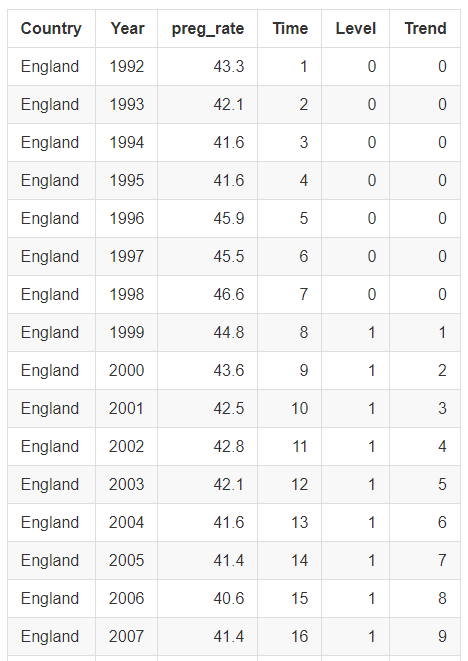

We can now fit a straightforward linear model to our data using the `lm` function and the formula we derived above. This will attempt to test whether the coefficients represent significant level and trend changes at 1999.

```r
# Check the equation above for what three variables to put to the right hand
# side of the `preg ~ ...` formula

england_mod <- lm(preg_rate ~ Time + Level + Trend, data = england_its_data)

summary(england_mod)
```

```
##
## Call:
## lm(formula = preg_rate ~ Time + Level + Trend, data = england_its_data)
##
## Residuals:
##    Min     1Q Median     3Q    Max
## -3.721 -2.537 -0.200  1.750  5.244
##
## Coefficients:
##             Estimate Std. Error t value Pr(>|t|)
## (Intercept)  40.8000     2.4244  16.829 1.15e-13 ***
## Time          0.7500     0.5421   1.383 0.181047
## Level         4.0167     2.4105   1.666 0.110493
## Trend        -2.2956     0.5576  -4.117 0.000491 ***
## ---
## Signif. codes:  0 '***' 0.001 '**' 0.01 '*' 0.05 '.' 0.1 ' ' 1
##
## Residual standard error: 2.869 on 21 degrees of freedom
## Multiple R-squared:  0.8985, Adjusted R-squared:  0.884
## F-statistic: 61.99 on 3 and 21 DF,  p-value: 1.329e-10
```

## Interpreting our model

The estimates of our four coefficients are shown above. Let’s interpret them according to our data.

> In England in 1991 there were approximately **40.8** pregnancies per 1,000 women aged under-18. This **increased** yearly by **0.75 more** pregnancies per year from 1992 to 1998.

(note that in making `Time` begin with 1 in 1992 we implicitly made 1991 our `Time = 0` baseline, rather than using `Year` directly and making 1 B.C.E. our baseline!)

> In 1999 at strategy launch England saw a change in yearly pregnancy rates of **4.02 more** pregnancies per 1,000 women aged under-18. This was a **non-significant** change in level (indepenent of trend changes).

> From 1999 onwards, England saw **a decreasing** trend of **2.30 fewer** pregnancies per 1,000 women aged under-18 per year. This was a **significant** change in trend.

(note that this is relative to the baseline trend)

## Graphing our model

We have fitted straight lines to our data. Now let’s plot those lines over our scatter point graph we made above to see how it fits.

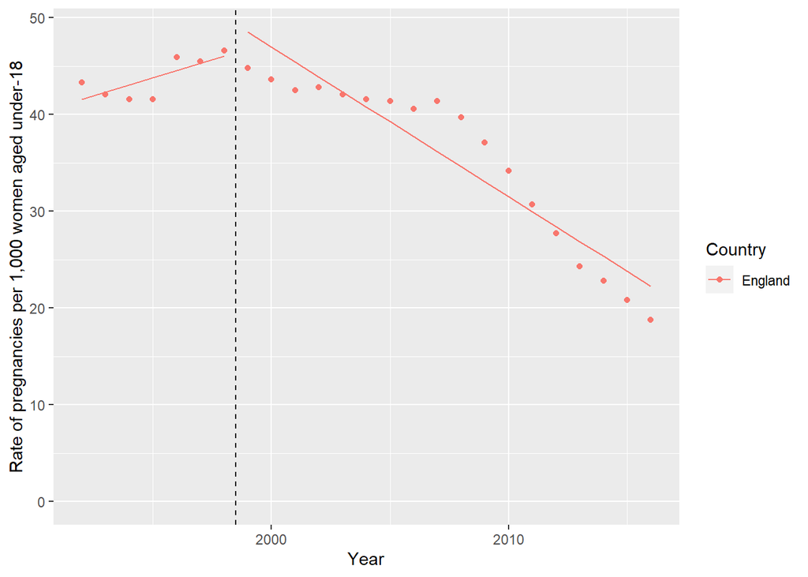

```r
eng_predict <- england_its_data %>%
  mutate(fitted = predict(england_mod))

eng_predict_plot <- eng_plot +
  geom_line(data = eng_predict, aes(y = fitted, group = Level))  # `group = Level` splits (segments)
                                                              # the line into pre/post strategy parts

eng_predict_plot
```

Your graph should look like [this](https://i.imgur.com/GbVbkKh.png).

**View inline in rendered file**

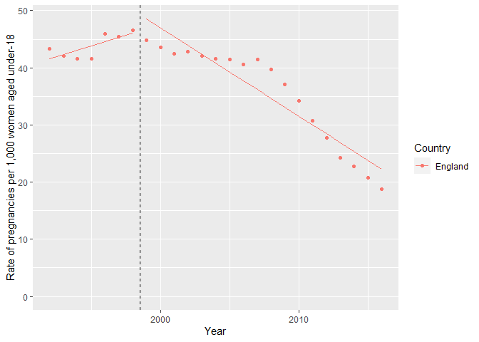

We can add to this a line representing our hypothesised ‘no strategy’ (counterfactual) England - following the baseline trends beyond the 1999 strategy. We first create a dummy dataset, then apply the same model.

```r
england_counterfactual <- england_its_data %>%
  filter(Year >= 1999) %>%
  mutate(Country = "No strategy",
         Level = 0,      # If England had not had a strategy,
         Trend = 0) %>%  # Level and Trend would have stayed at 0
  mutate(fitted = predict(england_mod, newdata = .))

# Have a look at your data and see if it looks right
england_counterfactual
```

| Country | Year | preg_rate | Time | Level | Trend | fitted |
| --- | --- | --- | --- | --- | --- | --- |
| No strategy | 1999 | 44.8 | 8 | 0 | 0 | 46.80 |
| No strategy | 2000 | 43.6 | 9 | 0 | 0 | 47.55 |
| No strategy | 2001 | 42.5 | 10 | 0 | 0 | 48.30 |
| No strategy | 2002 | 42.8 | 11 | 0 | 0 | 49.05 |
| No strategy | 2003 | 42.1 | 12 | 0 | 0 | 49.80 |
| No strategy | 2004 | 41.6 | 13 | 0 | 0 | 50.55 |
| No strategy | 2005 | 41.4 | 14 | 0 | 0 | 51.30 |
| No strategy | 2006 | 40.6 | 15 | 0 | 0 | 52.05 |
| No strategy | 2007 | 41.4 | 16 | 0 | 0 | 52.80 |
| No strategy | 2008 | 39.7 | 17 | 0 | 0 | 53.55 |

[output cut: 8 more lines]

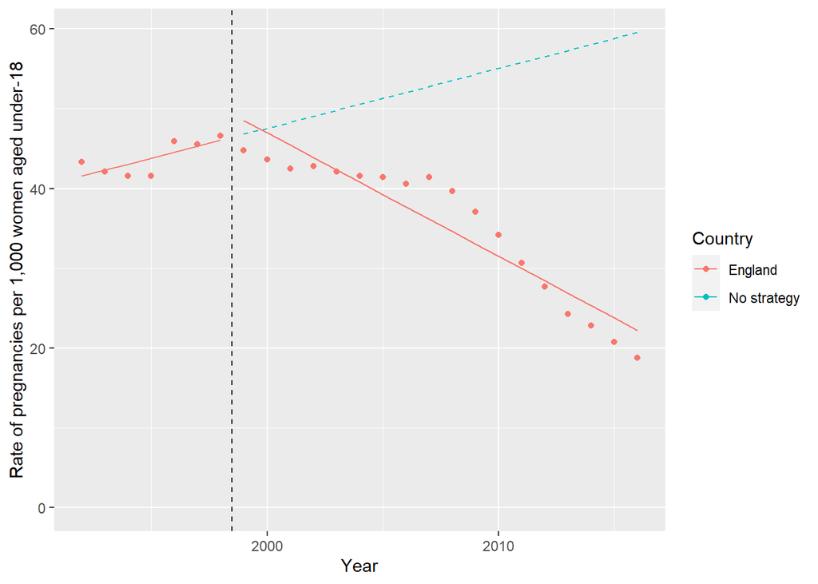

```r
eng_predict_plot +
  geom_line(data = england_counterfactual, aes(y = fitted), linetype = "dashed")
```

Your graph should look like [this](https://i.imgur.com/uWF1ZXw.png).

**View inline in rendered file**

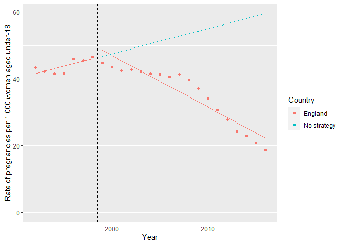

> If England had followed the 1991-1998 trend from 1999 onwards, what would have happened? Does it look like the Teenage Pregnancy Strategy was effective in lowering pregnancy rates?

# Using controls in interrupted time series

We’ll now extend our model by adding a control. In some analyses controls might not be possible or necessary. See Lopez Bernal et al., (2018) for some things to think through.

A key advantage of using a control is to adjust for other events and simultaneous interventions which might produce changes which *look* like they’re caused by the intervention, but would have happened anyway. In the case of teenage pregnancy in England, there could be quite a few other things affecting rates across the observation period. We could try adjusting for these using Scotland’s rates as a control, as Scotland was not exposed to the same strategy as England.

Let’s import a dataset of Scotland’s rates (from [ISD Scotland](https://www.isdscotland.org)) and compare:

```r
scotland <- read_csv("data/Scotland.csv") # Read in 'Scotland.csv' (in `data` folder)
scotland
```

| Country | Year | preg_rate |
| --- | --- | --- |
| Scotland | 1992 | 43.19952 |
| Scotland | 1993 | 41.27853 |
| Scotland | 1994 | 41.50000 |
| Scotland | 1995 | 40.70000 |
| Scotland | 1996 | 44.70000 |
| Scotland | 1997 | 43.80000 |
| Scotland | 1998 | 44.70000 |
| Scotland | 1999 | 43.00000 |
| Scotland | 2000 | 40.50000 |
| Scotland | 2001 | 39.20000 |

[output cut: 15 more lines]

These data are in the same format as England data above, so can be combined (with `Country` now able to distinguish the two countries as exposed/unexposed).

Let’s look at the yearly rates of both countries to see how they compare:

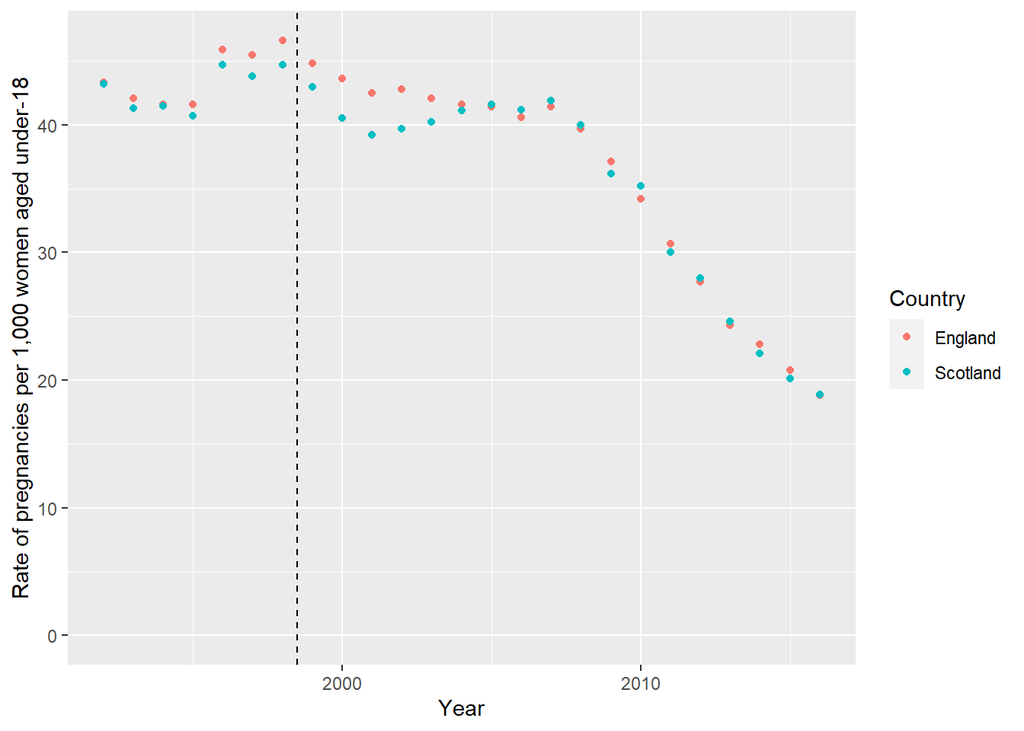

```r
eng_scot_rates <- bind_rows(england, scotland)

# graph both countries together - hint: your code for your first scatter plot
# should work here!

eng_scot_plot <- eng_scot_rates %>%
  ggplot(aes(x = Year, y = preg_rate, colour = Country)) +
  geom_point() +
  geom_vline(xintercept = 1998.5, linetype = "dashed") +
  ylab("Rate of pregnancies per 1,000 women aged under-18") +
  ylim(0, NA)

eng_scot_plot
```

Your graph should look like [this](https://i.imgur.com/2xhmhoN.png).

**View inline in rendered file**

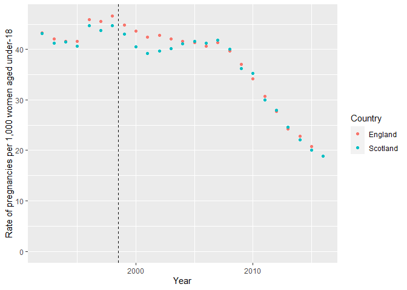

> What changes do you see in (unexposed) Scotland? How does this compare with England?

## Adding extra dummies and running controlled ITS model

To run a controlled ITS analyses we need a few extra coefficients (in addition to those defined above):

- Difference in baseline level between countries (‘Group’)
- Difference in baseline trend between countries (‘Group’ * ‘Time’)
- Difference in level change at 1999 (‘Group’ * ‘Level’)
- Difference in trend change at 1999 (‘Group’ * ‘Trend’)

These go in the following equation:

$Rate = \beta_0+\beta_1*Time+\beta_2*Group+\beta_3*Group*Time+\beta_4*Level+\beta_5*Trend+\beta_6*Group*Level+\beta_7*Group*Trend+\epsilon$

To do this we’ll create the dummy variables in our joined dataset:

- ‘Group’ will be 1 for England and 0 for Scotland
- ‘Group_time’ will be the multiplication of Group and Time - England will have an additional trend on top of the common ‘Time’ trend controlled for with Scotland
- ‘Group_level’ will be the multiplication of Group and Level - again giving England an additional level change only associated with exposure to the strategy.
- ‘Group_trend’ as the multiplication of Group and Trend - an additional trend change associated with exposure

For the joined dataset we can now create a full dummy dataset:

```r
eng_scot_its <- eng_scot_rates %>%
  mutate(
    Time = Year - 1991,
    Level = ifelse(Year >= 1999, 1, 0),
    Trend = ifelse(Year >= 1999, Year - 1998, 0),
    Group = ifelse(Country ==  "England", 1, 0),  # Set to 1 only for England
    Group_time =  Group * Time,
    Group_level =  Group * Level,
    Group_trend =  Group * Trend
  )

eng_scot_its
```

| Country | Year | preg_rate | Time | Level | Trend | Group | Group_time | Group_level | Group_trend |
| --- | --- | --- | --- | --- | --- | --- | --- | --- | --- |
| England | 1992 | 43.30000 | 1 | 0 | 0 | 1 | 1 | 0 | 0 |
| England | 1993 | 42.10000 | 2 | 0 | 0 | 1 | 2 | 0 | 0 |
| England | 1994 | 41.60000 | 3 | 0 | 0 | 1 | 3 | 0 | 0 |
| England | 1995 | 41.60000 | 4 | 0 | 0 | 1 | 4 | 0 | 0 |
| England | 1996 | 45.90000 | 5 | 0 | 0 | 1 | 5 | 0 | 0 |
| England | 1997 | 45.50000 | 6 | 0 | 0 | 1 | 6 | 0 | 0 |
| England | 1998 | 46.60000 | 7 | 0 | 0 | 1 | 7 | 0 | 0 |
| England | 1999 | 44.80000 | 8 | 1 | 1 | 1 | 8 | 1 | 1 |
| England | 2000 | 43.60000 | 9 | 1 | 2 | 1 | 9 | 1 | 2 |
| England | 2001 | 42.50000 | 10 | 1 | 3 | 1 | 10 | 1 | 3 |

[output cut: 40 more lines]

Your data should look like [this](https://i.imgur.com/0QWbNse.png).

**View inline in rendered file**

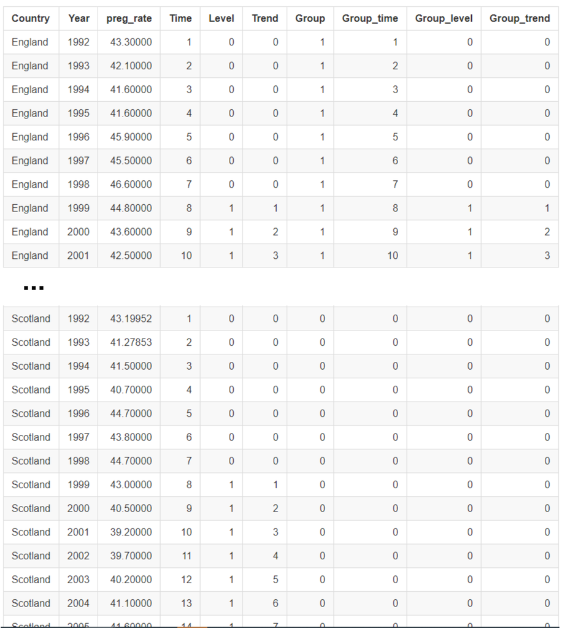

Now let’s fit a controlled model:

```r
# Use the equation above and your new variables to complete the formula

eng_scot_mod <-
  lm(preg_rate ~ Time + Group + Group_time + Level + Trend + Group_level + Group_trend,
     data = eng_scot_its
     )

summary(eng_scot_mod)
```

```
##
## Call:
## lm(formula = preg_rate ~ Time + Group + Group_time + Level +
##     Trend + Group_level + Group_trend, data = eng_scot_its)
##
## Residuals:
##     Min      1Q  Median      3Q     Max
## -4.5166 -2.5458 -0.2193  1.7438  6.5708
##
## Coefficients:
##             Estimate Std. Error t value Pr(>|t|)
## (Intercept)  41.0191     2.7311  15.019  < 2e-16 ***
## Time          0.4552     0.6107   0.745  0.46023
## Group        -0.2191     3.8623  -0.057  0.95503
## Group_time    0.2948     0.8636   0.341  0.73451
## Level         3.5792     2.7154   1.318  0.19461
## Trend        -1.8391     0.6281  -2.928  0.00549 **
## Group_level   0.4375     3.8402   0.114  0.90984
## Group_trend  -0.4565     0.8882  -0.514  0.60995
## ---
## Signif. codes:  0 '***' 0.001 '**' 0.01 '*' 0.05 '.' 0.1 ' ' 1
##
## Residual standard error: 3.231 on 42 degrees of freedom
## Multiple R-squared:  0.865,  Adjusted R-squared:  0.8426
## F-statistic: 38.46 on 7 and 42 DF,  p-value: 2.85e-16
```

<sup>Side note - `lm` *can* do interactions for us: `Group*Time` would automatically add the terms `Group + Time + Group:Time`, giving the interactions we need. However it’s perhaps simpler to explicitly create the variables and pass them to the function ourselves, both to keep them in the order we specified them and to aid reading the output</sup>

Now see what we can tell from our data.

> In 1991 Scotland had an estimated **41.0** pregnancies per 1,000 women aged under 18, and England had **0.22 fewer**.

> When the strategy launched in England in 1999, Scotland saw **an increase** in pregnancy rates of **3.58** per 1,000 women, whist England’s level change was **0.44 more** pregnancies than Scotland. This difference was **not significant**.

> Whilst not exposed to the strategy, Scotland saw a **significant decrease** in trend in pregnancies of **1.84** per 1,000 women each year. England’s rates **decreased** by **0.46** *in addition to Scotland’s trend change*. This difference was **not significant**.

(remember that these trend changes are relative. In Scotland’s case the trend change was relative to baseline. In England’s case the trend change was relative to the trend change seen in Scotland).

## Graphing its model with comparators

We can use our model to add prediction lines to both countries to see what the fitted models look like.

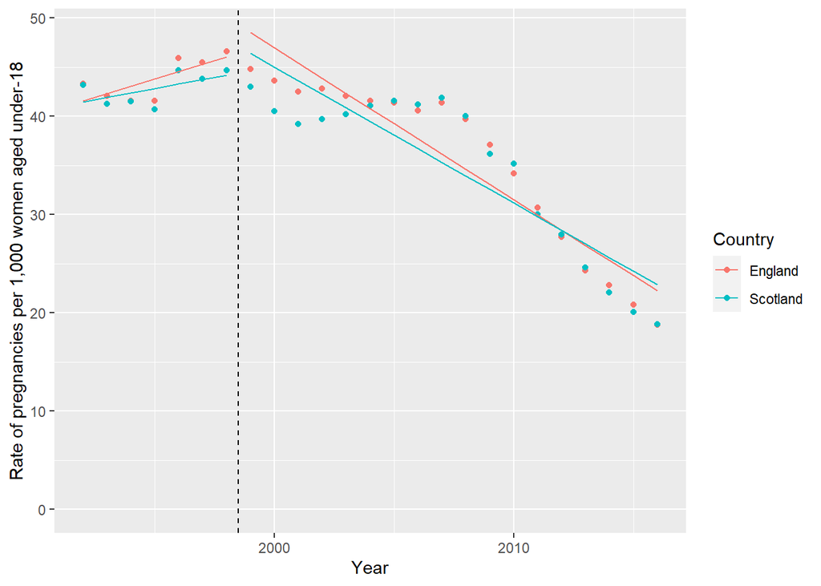

```r
eng_scot_predict <- eng_scot_its %>%
  mutate(fitted = predict(eng_scot_mod)) # pass the new model output to the `predict` function

eng_scot_predict_plot <- eng_scot_plot +
  geom_line(data = eng_scot_predict, aes(
    y =  fitted,
    group = interaction(Level, Country),  # These two lines make a break at 1999 and preserve colours according to country
    colour = Country
  ))

eng_scot_predict_plot
```

Your graph should look like [this](https://i.imgur.com/L4P20LC.png).

**View inline in rendered file**

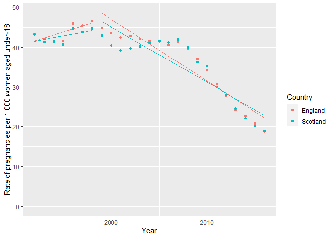

We can further add a predicted line for the proposed path England’s rates would have followed if it had seen the same effects as Scotland (i.e. in the absence of the strategy whilst controlling for confounders). This is a little trickier! We again need to create a dummy dataset.

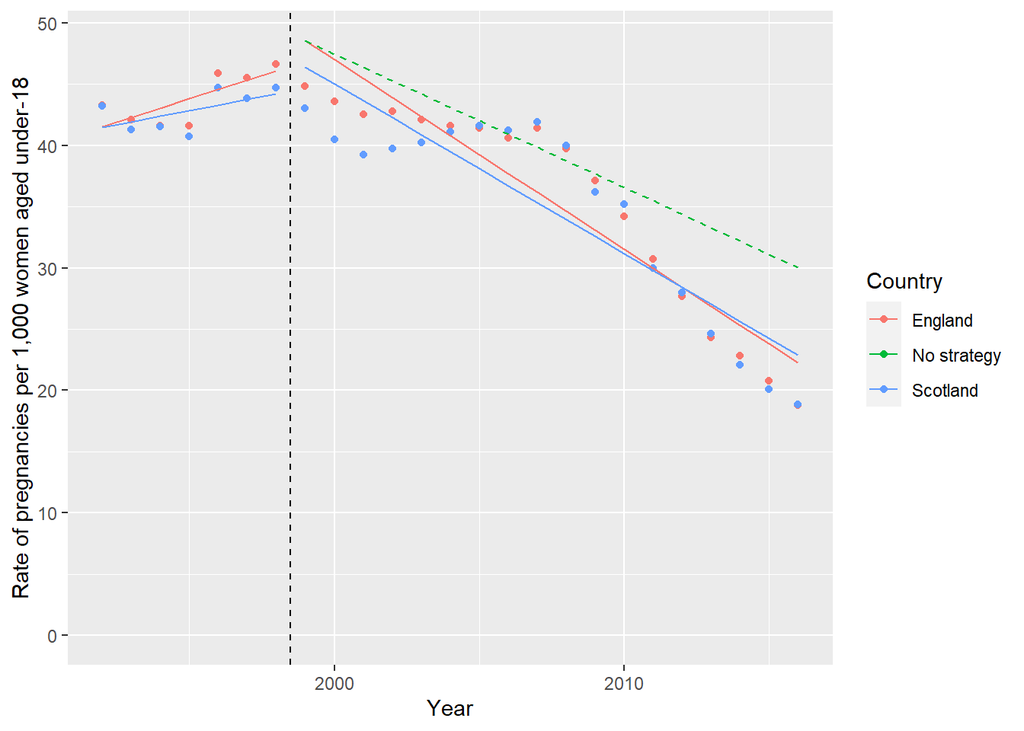

```r
eng_scot_counterfactual <- eng_scot_its %>%
  filter(Country == "England", Year >= 1999) %>%
  mutate(Country = "No strategy",
         Group_level = 0,
         Group_trend = 0) %>%  # In the absence of the strategy both of these terms would be ...?
  mutate(fitted = predict(eng_scot_mod, newdata = .))  # pass in new model

eng_scot_predict_plot +
  geom_line(data = eng_scot_counterfactual, aes(y = fitted), linetype = "dashed")
```

Your graph should look like [this](https://i.imgur.com/Sqo1RGI.png).

**View inline in rendered file**

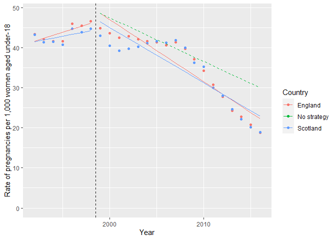

> Did exposure to the strategy make England’s rates fall faster than in unexposed Scotland? Did the strategy contribute to falling teenage pregnancy rates? Are there potentially other UK-wide (or worldwide?) events which could have contributed to falling rates, independent of the strategy?

# Drawing conclusions

You’ve hopefully now seen what can be tested using an interrupted time series analysis, and the potential advantages of using a control. This is an introduction to using ITS to evaluate a policy, but there will likely be more things to address in analyses like this one:

- How well fitted are the linear models, and do other elements (like seasonality and known events) need to be added to the model to give a more accurate picture?
- Was the model of level and trend change the best one to use? In our example, would omitting the ‘Level’ change variable (i.e. assuming no ‘immediate’ effects of the strategy on 1999 rates) better fit the data?
- The data may be affected by autocorrelation. Correcting for this is important but beyond the scope of this practical (see Lopez Bernal et al., 2017 for some other pointers).
- Is the control appropriate to give estimates of unexposed trends? Is the control trend likely to have been affected (directly or indirectly) by the tested exposure also? Here we have used a control country recording the same outcome (pregnancy rates). In some cases it might be better to use an unaffected outcome in the same population.

# Going further

To cover the advanced aspects of this regression-based approach to interrupted time series analysis, I can recommend the course [Policy analysis using interrupted time series](https://www.edx.org/course/policy-analysis-using-interrupted-time-series), available for free on edx. This will cover the further elements of testing for and correcting for autocorrelation, as well as correcting for other things observed in the data.

To explore the analyses we’ve just done here, and conduct a repeat comparison using Wales’s rates as a control, I created a [Shiny app](https://phd.andybaxter.me/ITS_shinyapp/) which runs the same syntax on the same data in R, but with an interactive user interface. The fuller publication of this analysis can be found [here](https://www.sciencedirect.com/science/article/pii/S0277953621000174) (including next week’s subject of synthetic control analysis to approach the same problem).

Get in touch through Classrooms if you have any questions!